# Programming Assigent 1. Reproducible Research

### Imputing missing values

Let’s start by calculating the number of NAs we have

```r
total_na <- sum(is.na(fitdata$steps))
total_na
```

```
## [1] 2304
```

To fill the not available values we are going to use the mean steps in each interval

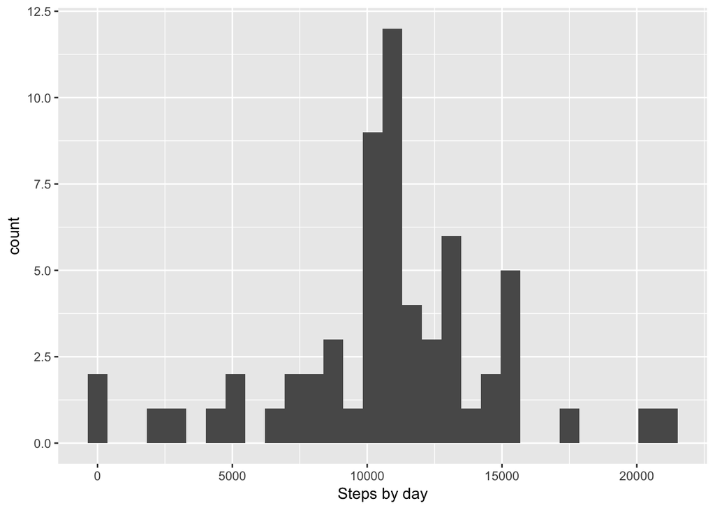

```r
fitdata2 <- fitdata
fitdata2$steps[is.na(fitdata2$steps)] <- tapply(fitdata$steps, fitdata$interval, mean, na.rm =TRUE)
fitdata_group2 <- tapply(fitdata2$steps, fitdata2$date, sum)
qplot(fitdata_group2, xlab = "Steps by day")
```

```r
mean(fitdata_group2)
```

```
## [1] 10766.19
```

```r
median(fitdata_group2)
```

```
## [1] 10766.19
```

### Differences in weekdays

We add a new fied for the type of day and fill it with weekday or weekend

```r
library(dplyr)
```

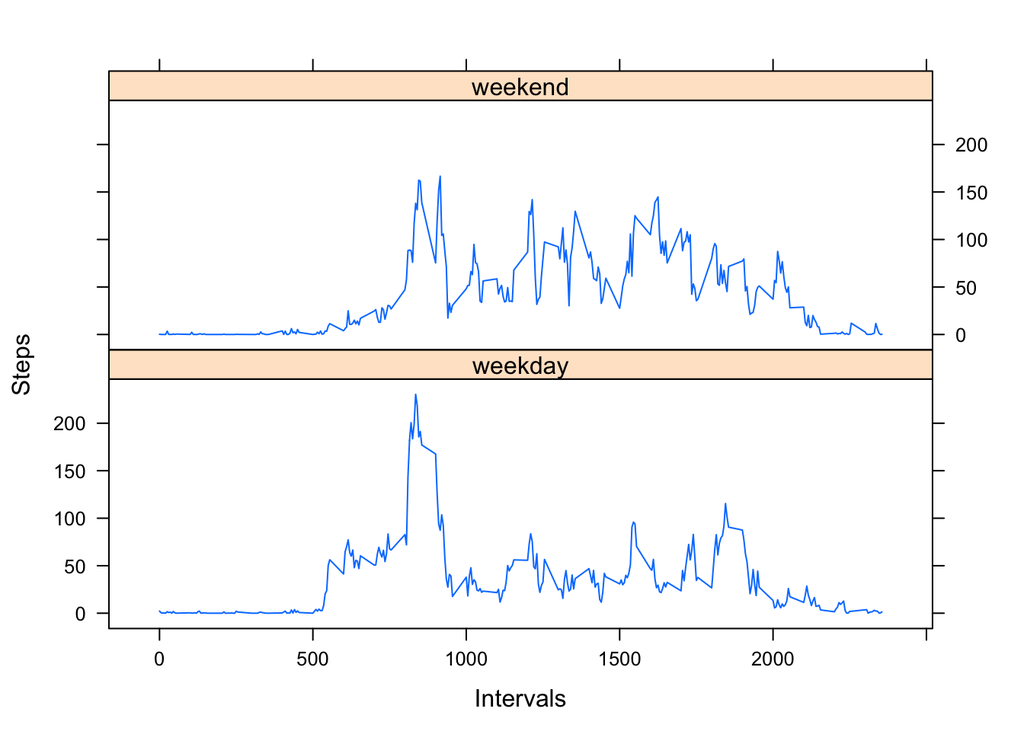

```r
fitdata2$day <- weekdays(fitdata2$date)
fitdata2$day[fitdata2$day == "Saturday" | fitdata2$day == "Sunday"] <- "weekend"
fitdata2$day[fitdata2$day == "Monday" | fitdata2$day == "Tuesday"| fitdata2$day == "Wednesday"| fitdata2$day == "Thursday"| fitdata2$day == "Friday"] <- "weekday"
fitdataday <- filter(fitdata2, day == "weekday")
fitdataend <- filter(fitdata2, day == "weekend")
fitdata_timeday <- tapply(as.numeric(fitdataday$steps), fitdataday$interval, mean, na.rm =TRUE)
fitdata_timeend <- tapply(as.numeric(fitdataend$steps), fitdataend$interval, mean, na.rm =TRUE)
times2 <- unique(fitdata2$interval)
fitdata_timeday <- cbind(fitdata_timeday, times2, "weekday")
fitdata_timeend <- cbind(fitdata_timeend, times2, "weekend")
fitdata_time2 <- rbind(fitdata_timeday, fitdata_timeend)
library(lattice)
xyplot(as.numeric(fitdata_time2[,1])~as.numeric(fitdata_time2[,2]) | fitdata_time2[,3], layout = c(1,2), type = "l", lty = 1, xlab = "Intervals", ylab = "Steps")
```

We can see several differences between weekdays and weekends. People start to walk earlier at weekdays, but later the number of steps decreases a lot.